# Session Fourteen: Creating Packages

Estimated Duration: 40 minutes

**<<** Back to Menu

## 1. Create Package

### **Part 1: “Hello, World” Package**

The objective of this exercise is to understand the basic steps to create a package for your own use or within your internal working environment.

#### Step 1 - New Project Wizard

Create a new package using RStudio’s New Project Wizard.

- Go to File, New Project, New Directory, R Package.
- Enter the new package name “hello”.

[figure not shown]

- Click Create Project.

  A new folder hello is created in the default directory, together with all the required folders and templates to build a package almost immediately.

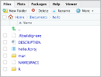

#### Step 2 – Review .R and .Rd Files

- In the **R folder** - the .R file contains the hello function which prints “Hello, world!” when the code is run.
- In the **man folder** - the .Rd file is a help document describing the purpose of the function. There is no need to make any changes to the contents of either files since RStudio has put in all the minimum required information.

#### Step 3 – Edit DESCRIPTION

The fields in the DESCRIPTION file are required to be updated. Replace the original information with your own information such as below.

```
Package: hello
Type: Package
Title: Hello, World!
Version: 0.1.0
Author: Stan
Maintainer: Stan <shtan06@gmail.com>
Description: The hello package contains a single function named hello.
It prints the word "Hello, world!".
License: GPL-2
Encoding: UTF-8
LazyData: true
```

#### Step 4 – Perform a Check

- Go to the Build tab in the environment pane.
- Click the Check button

If the check status is successful, you can now proceed to build the package.

#### Step 5 – Build Package

- In the Build tab, click on the More button and select Clean and Rebuild from the drop-down list.
- The package creation is complete when you see the “* DONE (hello)” message.
- Note where the package files are stored in your system. The path will be displayed during the build process, for example (for Mac):  
  installing to library ‘/Library/Frameworks/R.framework/Versions/4.0/Resources/library’

#### Step 6 – Finally, Test the Package

- In the Packages tab, check to make sure that the package has been installed and loaded.
- Execute the hello() function.
- Type ?hello to open the help file

## 2. Create Another Package

### **Part 2: Create Another Package Containing Multiple Functions**

This time, we create another package which we name “savings”. It will contain two financial functions.

#### Step 1 – Create R Package from New Project Wizard

Repeat step 1 as above, but name the package “savings”.

#### Step 2 – Create a .R File

Delete the hello.R file if it is in the R folder and open a new R Script file. Insert the following code (or if you already have an existing savings.R file, it can be added during the “Create R Package” process).

```
# Function 1
savings <- function(p,r,t)
# where p=initial principal, r=periodic interest, t=no. of periods
  {
  finalbalance <- p*(1+r/100)^t  # balance as at end of period t
  interestearned <- finalbalance-p # total interest earned
  totalreturn <- (finalbalance-p)/p*100 # total return in percentage

  print(paste("Final Balance ($):",toString(finalbalance)), quote = FALSE)
  print(paste("Interest Earned ($):",toString(interestearned)), quote = FALSE)
  print(paste("Return (%):",toString(totalreturn)), quote = FALSE)
  }

# Function 2
intrate <- function(p,f,t){((f/p)^(1/t)-1)*100}

# calculates periodic interest given initial and target amounts over a specified period
# where p=initial interest, f=final balance, t=no. of periods
```

- Test the functions to make sure there are no errors.
- Clear the environment and save the file as savings.R in the R folder.

#### Step 3 – Edit and Add Files Created in the Project Folder

The following files must be edited or manually created.

- DESCRIPTION
- LICENSE
- Help files

Fill in as much information as possible. The package cannot be built if there are missing files and information. As checks are being performed, error messages and warnings will guide you to which fields need to be populated.

**a) DESCRIPTION**

This file is automatically created with the project. Edit or add details for each field. For example:

```
Package: savings
Type: Package
Title: Savings Calculator
Version: 0.1.0
Author: Stan
Maintainer: Stan <shtan06@gmail.com>
Description: This package contains 2 functions. The savings function calculates
the balance, interest earned and return at the end of the period. The intrate
function calculates the annual interest required for an initial savings amount
to reach a certain amount at the end of a specified period.
License: file LICENSE
Encoding: UTF-8
LazyData: true
```

Note that the name “savings” on the first line will be taken by R as the name of the package.

**b) LICENSE**

You need to create this file if your license stated in DESCRIPTION refers to a file.

- Go to File > New File > Text File
- Add wordings to the file such as “This package belongs to me. Please ask for permission to distribute.”
- Save the file as LICENSE to the main project folder.

**c) Help Files**

You can use the existing hello.Rd template to customise according to the savings package. If the “man” folder is empty, you can also create a new help file:

- Go to File > New File > R Documentation
- Enter a topic name (which should the name of the function) and accept the default Rd template: function. Click OK.

The new help file is a template which requires some editing. Below are the edited help files for the savings example. Two help files have been created, one for each function.

**SavingsHelpFile.Rd**

```
\name{savings}
\alias{savings}
%- Also NEED an '\alias' for EACH other topic documented here.
\title{Calculate Savings
%%  ~~function to do ... ~~
}
\description{This package contains 2 functions. The savings function calculates
the balance, interest earned and return at the end of the period. The intrate
function calculates the annual interest required for an initial savings amount
to reach a certain amount at th end of a specified period.
%%  ~~ A concise (1-5 lines) description of what the function does. ~~
}
\usage{
savings(p,r,t)
}
%- maybe also 'usage' for other objects documented here.
\arguments{
  \item{p,r,t}{
%%     ~~Describe \code{x} here~~
}
}
\details{no details
%%  ~~ If necessary, more details than the description above ~~
}
\value{returns end balance, interest earned and returns
%%  ~Describe the value returned
%%  If it is a LIST, use
%%  \item{comp1 }{Description of 'comp1'}
%%  \item{comp2 }{Description of 'comp2'}
%% ...
}
\references{no references
%% ~put references to the literature/web site here ~
}
\author{STan
%%  ~~who you are~~
}
\note{no note
%%  ~~further notes~~
}
```

[output cut: 10 more lines]

```

## The function is currently defined as
function (p,r,t)
{
 }
}
% Add one or more standard keywords, see file 'KEYWORDS' in the
% R documentation directory (show via RShowDoc("KEYWORDS")):
% \keyword{ ~kwd1 }
% \keyword{ ~kwd2 }
% Use only one keyword per line.
% For non-standard keywords, use \concept instead of \keyword:
% \concept{ ~cpt1 }
% \concept{ ~cpt2 }
% Use only one concept per line.
```

**IntRateHelpFile.Rd**

```
\name{intrate}
\alias{intrate}
%- Also NEED an '\alias' for EACH other topic documented here.
\title{Calculate Interest
%%  ~~function to do ... ~~
}
\description{This package contains 2 functions. The savings function calculates
the balance, interest earned and return at the end of the period. The intrate
function calculates the annual interest required for an initial savings amount
to reach a certain amount at th end of a specified period.
%%  ~~ A concise (1-5 lines) description of what the function does. ~~
}
\usage{
intrate(p,f,t)
}
%- maybe also 'usage' for other objects documented here.
\arguments{
 \item{p,f,t}{
%%     ~~Describe \code{x} here~~
}
}
\details{no details
%%  ~~ If necessary, more details than the description above ~~
}
\value{return in percentage terms
%%  ~Describe the value returned
%%  If it is a LIST, use
%%  \item{comp1 }{Description of 'comp1'}
%%  \item{comp2 }{Description of 'comp2'}
%% ...
}
\references{no references
%% ~put references to the literature/web site here ~
}
\author{Stan
%%  ~~who you are~~
}
\note{no note
%%  ~~further notes~~
}
```

[output cut: 10 more lines]

```

## The function is currently defined as
function (p,f,t)
{
 }
}
% Add one or more standard keywords, see file 'KEYWORDS' in the
% R documentation directory (show via RShowDoc("KEYWORDS")):
% \keyword{ ~kwd1 }
% \keyword{ ~kwd2 }
% Use only one keyword per line.
% For non-standard keywords, use \concept instead of \keyword:
% \concept{ ~cpt1 }
% \concept{ ~cpt2 }
% Use only one concept per line.
```

#### Step 4 – Perform a Check

- Same as step 4 above

#### Step 5 – Build Package

- Same as step 5 above but use functions savings instead.

#### Step 6 – Finally, Test the Package

- In the Packages tab, check to make sure that the package has been installed and loaded.
- Execute the savings() and intrate() functions.
- Type ?savings and ?intrate to open the help file

## 3. Add Data to the Package

### **Part 3: Add Data to the Package**

To store data in the package, we need to create an object (in this exercise, it will be a data frame), a data folder, .RData file and a help file.

#### Step 1 – Create a Data Folder

- Manually create a folder named “data” in the parent directory.

#### Step 2 – Create a Data Frame

Open a new R Script file and create a data frame by either pulling data from a source or enter the data within the code. For example:

```
account <- data.frame(
  name=c("Savings 1","Savings 2","Savings 3","FD 1","FD 2"),
  rate=c(3.3, 4.1, 2.9, 3.5, 3.65))

# in case, "Object named ‘.Random.seed’ found in dataset:" appears
# remove this object from the environment using rm(.Random.seed)
# Another note: all data must be defined within the emp variable
# do not:
# name <- c("Savings 1", Savings 2")
# rate <- c(3.3, 4.1)
# emp <- (name, rate)
```

- Run the script and check if the data appears in the environment.
- Save the R Script file in the R folder and name it as account.
- Save the environment as account.RData in the data folder.

#### Step 3 – Edit NAMESPACE

- The .R data file in R folder must be ignored by NAMESPACE, so the default alpha text must be removed, to replaced by export(function name) for each function.

#### Step 5 – Perform a Check

- Same as step 4 of the previous section.

#### Step 6 – Build Package

- Same as step 5 of the previous function.

## 4. Summary

### **Part 4: Summary**

#### Useful Tools for Creating Packages

- Package.skeleton – helps to create the structure
- roxygen2 helps documenting packages easy
- devtools makes checking and building packages easy

#### Further Reading

1. R Packages by Hadley Wickham http://r-pkgs.had.co.nz/
2. RStudio Support https://support.rstudio.com/hc/en-us/sections/200130627-Package-Development

[^1]Contact

[^1]: shtan06@gmail.com